# PLM and DiD models for UKBB

```r
suppressPackageStartupMessages(suppressWarnings({
    library(dplyr)
    library(data.table)
    library(dplyr)
    library(TwoSampleMR)
    library(plm)
    library(knitr)
}))
opts_chunk$set(warning=FALSE, message=FALSE, cache=TRUE, echo=TRUE)
```

## Simulations to see if DiD and PLM give the same estimates

```r
n <- 100000
g <- rbinom(n, 2, 0.5)
x <- g + rnorm(n)
y <- 2 * x + rnorm(n)

fam <- rep(1:(n/2), each=2)
sib <- rep(1:2, times=n/2)

dat <- data_frame(g,x,y,fam,sib)

dat1 <- subset(dat, sib==1)
dat2 <- subset(dat, sib==2)

dif <- data_frame(
    g = dat1$g - dat2$g,
    x = dat1$x - dat2$x,
    y = dat1$y - dat2$y
)
```

Get the Wald ratio using DiD estimate:

```r
coefficients(lm(y ~ g, dif))[2] / coefficients(lm(x ~ g, dif))[2]
```

```
##        g
## 2.001698
```

Get the PLM estimate:

```r
plm(y ~ x | g, data=dat, index="fam", model="within", inst.method="bvk")
```

```
##
## Model Formula: y ~ x | g
## <environment: 0x31ec8e30>
##
## Coefficients:
##      x
## 2.0017
```

Note that DiD ran instantly but PLM took about 20 seconds

## Compare PLM and DiD in UKBB data

Read in the data

```r
setwd("/projects/MRC-IEU/research/projects/ieu2/p1/002/working/data/")
load("ukbb/data_sibs")
```

Create sib pairs for DiD model:

```r
a <- merge(data_sibs, data_sibs, by="famid", allow.cartesian=TRUE)
a <- subset(a, n_eid.x > n_eid.y)
dim(a)
```

```
## [1] 17829  1091
```

Here `a` is just all the variables combined together by sibling pair. So a variable called `n_eid` in the original `data_sibs` is now present twice, called `n_eid.x` and `n_eid.y` for each sib pair.

Using these data we can get the DiD estimates for each SNP using this function, adapted from the one used in the simulations but methodologically identical.

```r
do_mr_wf_tab <- function(dat, inst, x, y)
{
    nsnp <- length(inst)
    sbx <- rep(NA, nsnp)
    sby <- rep(NA, nsnp)
    ssex <- rep(NA, nsnp)
    ssey <- rep(NA, nsnp)
    sdiffx <- dat[[paste0(x, ".x")]] - dat[[paste0(x, ".y")]]
    sdiffy <- dat[[paste0(y, ".x")]] - dat[[paste0(y, ".y")]]
    for(i in 1:nsnp)
    {
        sdiffgx <- dat[[paste0(inst[i], ".x")]] - dat[[paste0(inst[i], ".y")]]
        mod <- summary(lm(sdiffx ~ sdiffgx))
        sbx[i] <- coefficients(mod)[2,1]
        ssex[i] <- coefficients(mod)[2,2]
        mod <- summary(lm(sdiffy ~ sdiffgx))
        sby[i] <- coefficients(mod)[2,1]
        ssey[i] <- coefficients(mod)[2,2]
    }
    return(data_frame(inst, sbx, sby, ssex, ssey))
    # return(mr_ivw(sbx, sby, ssex, ssey))
}
```

Note, it returns the exposure and outcome effect estimates for each SNP instead of the MR IVW estimate, so it’s a bit more flexible in allowing us to investigate the results.

Get the DiD estimates for the first 20 SNPs, for exposure = eduyears2 and outcome = out_height

```r
rsid <- grep("^rs", names(data_sibs), value=TRUE)[1:20]
DiD <- do_mr_wf_tab(a, rsid, "eduyears2", "out_height")
```

Estimate the Wald ratios:

```r
DiD$b <- DiD$sby / DiD$sbx
kable(DiD)
```

| inst | sbx | sby | ssex | ssey | b |
| --- | --- | --- | --- | --- | --- |
| rs425277_T_C | -0.0122265 | -0.0503659 | 0.0715704 | 0.1289374 | 4.1194226 |
| rs1074078_T_C | 0.0348443 | 0.2164715 | 0.0674353 | 0.1214783 | 6.2125417 |
| rs2284746_G_C | -0.0485577 | 0.1600238 | 0.0639450 | 0.1151959 | -3.2955390 |
| rs7542242_T_C | -0.0177739 | -0.2513542 | 0.0686858 | 0.1237271 | 14.1417620 |
| rs2806561_G_A | 0.0022560 | -0.1035458 | 0.0638657 | 0.1150548 | -45.8982071 |
| rs17257113_A_G | -0.0161798 | 0.2256003 | 0.0842128 | 0.1517046 | -13.9433532 |
| rs593133_C_T | 0.0197052 | 0.2589426 | 0.0763982 | 0.1376220 | 13.1407929 |
| rs6600365_T_C | 0.0760734 | -0.1756948 | 0.0646221 | 0.1164172 | -2.3095418 |
| rs9429088_A_T | -0.0857595 | -0.0812496 | 0.0636387 | 0.1146526 | 0.9474121 |
| rs564914_T_A | -0.0467899 | -0.0699317 | 0.0644347 | 0.1160830 | 1.4945903 |
| rs12065210_T_C | -0.2181888 | 0.3297068 | 0.1087374 | 0.1959028 | -1.5111080 |
| rs6691924_T_C | -0.0274657 | 0.2415858 | 0.0999212 | 0.1800046 | -8.7959192 |
| rs2815379_G_A | -0.0947924 | -0.0819138 | 0.0706902 | 0.1273571 | 0.8641386 |
| rs17391694_T_C | -0.0627057 | 0.4593893 | 0.0906145 | 0.1632127 | -7.3261208 |
| rs7551732_A_T | -0.0949627 | 0.0604362 | 0.0654168 | 0.1178579 | -0.6364199 |
| rs2811594_G_A | 0.0529727 | 0.1317342 | 0.0666948 | 0.1201522 | 2.4868345 |
| rs7517682_A_G | -0.0055882 | -0.1968302 | 0.0649953 | 0.1170832 | 35.2222308 |
| rs3790598_A_G | -0.0216243 | -0.0416378 | 0.0875344 | 0.1576978 | 1.9255117 |
| rs7536458_G_T | -0.0924688 | -0.1261200 | 0.0734539 | 0.1323336 | 1.3639197 |
| rs9782976_C_T | 0.1850341 | 0.0195072 | 0.1126650 | 0.2029872 | 0.1054246 |

Get the causal effect estimates for each of the 20 SNPs using PLM

```r
PLM <- list()
for(i in 1:length(rsid))
{
    f <- as.formula(paste0("out_height ~ eduyears2 | ", rsid[i]))
    temp <- plm(f, data=data_sibs, index="famid", model="within", inst.method="bvk") %>% summary %>% coefficients
    PLM[[i]] <- data_frame(inst=rsid[i], b = temp[1], se=temp[2], pval=temp[4])
}
```

```r
PLM <- bind_rows(PLM)
kable(PLM)
```

| inst | b | se | pval |
| --- | --- | --- | --- |
| rs425277_T_C | 4.7861193 | 27.751733 | 0.8630764 |
| rs1074078_T_C | 5.8075657 | 10.868087 | 0.5930935 |
| rs2284746_G_C | -4.3236733 | 7.011159 | 0.5374512 |
| rs7542242_T_C | 17.2462376 | 99.303757 | 0.8621257 |
| rs2806561_G_A | 220.8300605 | 45590.696238 | 0.9961353 |
| rs17257113_A_G | -21.3745073 | 238.641704 | 0.9286321 |
| rs593133_C_T | 38.8006150 | 425.736472 | 0.9273843 |
| rs6600365_T_C | -2.2500703 | 3.004431 | 0.4539176 |
| rs9429088_A_T | 1.1195562 | 1.517418 | 0.4606442 |
| rs564914_T_A | 0.9362968 | 1.920526 | 0.6258955 |
| rs12065210_T_C | -1.3489719 | 1.202515 | 0.2619668 |
| rs6691924_T_C | -6.1941191 | 17.088111 | 0.7169970 |
| rs2815379_G_A | 0.6570173 | 1.278887 | 0.6074395 |
| rs17391694_T_C | -4.5930878 | 5.125424 | 0.3701919 |
| rs7551732_A_T | -0.8762771 | 1.536836 | 0.5685615 |
| rs2811594_G_A | 3.2821119 | 5.387805 | 0.5424172 |
| rs7517682_A_G | -54.6072056 | 1000.034832 | 0.9564536 |
| rs3790598_A_G | 3.8113842 | 21.874411 | 0.8616794 |
| rs7536458_G_T | 1.0504710 | 1.368568 | 0.4427539 |
| rs9782976_C_T | 0.2000225 | 1.289157 | 0.8766989 |

How do they compare?

```r
cor(PLM$b, DiD$b)
```

```
## [1] -0.7359306
```

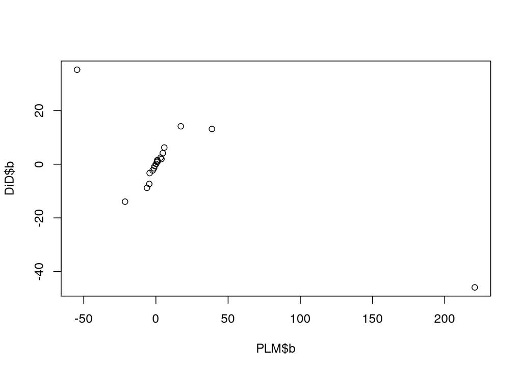

```r
plot(PLM$b, DiD$b)
```

When the estimates are small they are generally in agreement, but there are some totally wild estimates. This is probably because they are not instruments for eduyears2. Do it again but restrict to SNPs that strongly associate with eduyears2

## Finding instruments for eduyears2

```r
rsid <- grep("^rs", names(data_sibs), value=TRUE)
pval <- rep(NA, length(rsid))
for(i in 1:length(rsid))
{
    f <- as.formula(paste0("eduyears2 ~ ", rsid[i], " + ", paste(paste0("pc", 1:40), collapse=" + ")))
    pval[i] <- summary(lm(f, data=subset(data_sibs, !duplicated(famid))))$coefficients[2,4]
}
sum(pval < 0.05 / length(rsid))
```

```
## [1] 0
```

None of these variants associate with education? Try height

## Finding instruments for height

```r
pval <- rep(NA, length(rsid))
for(i in 1:length(rsid))
{
    f <- as.formula(paste0("out_height ~ ", rsid[i], " + ", paste(paste0("pc", 1:40), collapse=" + ")))
    pval[i] <- summary(lm(f, data=subset(data_sibs, !duplicated(famid))))$coefficients[2,4]
}
sum(pval < 0.05 / length(rsid))
```

```
## [1] 20
```

```r
min(pval)
```

```
## [1] 6.860906e-10
```

We find some instruments for height. Try the MR estimates again but do height -> edu and use the significant height SNPs

## Comparison of PLM and DiD in UKBB using strong instruments for height

```r
rsid_sig <- rsid[pval < 0.05 / length(rsid)]
DiD <- do_mr_wf_tab(a, rsid_sig, x = "out_height", y = "eduyears2")
DiD$b <- DiD$sby / DiD$sbx
PLM <- list()
for(i in 1:length(rsid_sig))
{
    f <- as.formula(paste0("eduyears2 ~ out_height | ", rsid_sig[i]))
    temp <- plm(f, data=data_sibs, index="famid", model="within", inst.method="bvk") %>% summary %>% coefficients
    PLM[[i]] <- data_frame(inst=rsid_sig[i], b = temp[1], se=temp[2], pval=temp[4])
}
```

```r
PLM <- bind_rows(PLM)

cor(PLM$b, DiD$b)
```

```
## [1] 0.979798
```

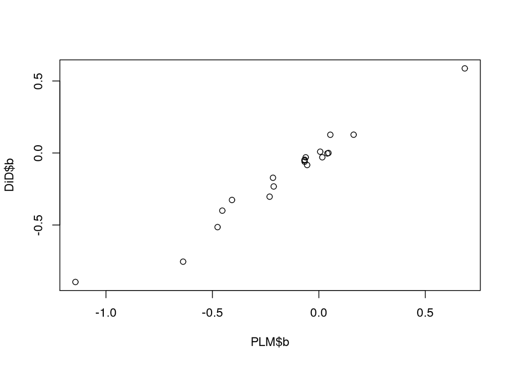

```r
plot(PLM$b, DiD$b)
```

Ok now there is very strong agreement

## Summary

When the instruments show some indication of association with the exposure then we are getting very strong agreement between PLM and DiD, but it’s not perfect. Going forwards, we can use IVW, median and mode estimators on DiD estimates; e.g.

```r
mr_ivw(DiD$sbx, DiD$sby, DiD$ssex, DiD$ssey)
```

```
## $b
## [1] -0.06719414
##
## $se
## [1] 0.04107072
##
## $pval
## [1] 0.1018272
##
## $nsnp
## [1] 20
##
## $Q
## [1] 18.21855
##
## $Q_df
## [1] 19
##
## $Q_pval
## [1] 0.5078864
```

Similarly -

```r
mr_weighted_median(DiD$sbx, DiD$sby, DiD$ssex, DiD$ssey)
mr_weighted_mode(DiD$sbx, DiD$sby, DiD$ssex, DiD$ssey)
```

[output not shown]

We can also meta analyse the PLM estimates, but need to think about how to do the pleiotropy robust methods because by default we need the exposure and outcome SNP effects, not the actual ratios.

```r
meta::metagen(PLM$b, PLM$se)
```

```
##                       95%-CI %W(fixed) %W(random)
## 1  -0.2313 [-0.9664; 0.5038]       1.4        1.4
## 2  -0.0678 [-0.4965; 0.3609]       4.1        4.1
## 3  -0.6376 [-2.0698; 0.7945]       0.4        0.4
## 4  -0.2121 [-0.5537; 0.1295]       6.4        6.4
## 5  -0.4757 [-1.1043; 0.1528]       1.9        1.9
## 6  -1.1434 [-4.0021; 1.7153]       0.1        0.1
## 7  -0.0617 [-0.3175; 0.1942]      11.4       11.4
## 8  -0.0668 [-0.3805; 0.2469]       7.6        7.6
## 9  -0.4535 [-2.5350; 1.6281]       0.2        0.2
## 10 -0.0549 [-0.3349; 0.2250]       9.5        9.5
## 11  0.0064 [-0.1931; 0.2058]      18.7       18.7
## 12  0.6854 [-0.4793; 1.8500]       0.5        0.5
## 13 -0.0668 [-0.4726; 0.3389]       4.5        4.5
## 14 -0.2155 [-1.0086; 0.5777]       1.2        1.2
## 15  0.0539 [-0.6893; 0.7970]       1.3        1.3
## 16  0.0162 [-0.2926; 0.3250]       7.8        7.8
## 17 -0.4080 [-1.0688; 0.2528]       1.7        1.7
## 18  0.0400 [-0.3255; 0.4054]       5.6        5.6
## 19  0.0450 [-0.2367; 0.3267]       9.4        9.4
## 20  0.1634 [-0.1780; 0.5047]       6.4        6.4
##
## Number of studies combined: k = 20
##
##                                         95%-CI     z p-value
## Fixed effect model   -0.0386 [-0.1249; 0.0477] -0.88  0.3811
## Random effects model -0.0386 [-0.1249; 0.0477] -0.88  0.3811
##
## Quantifying heterogeneity:
## tau^2 = 0; H = 1.00 [1.00; 1.00]; I^2 = 0.0% [0.0%; 0.0%]
##
## Test of heterogeneity:
##     Q d.f. p-value
##  9.74   19  0.9591
##
## Details on meta-analytical method:
## - Inverse variance method
## - DerSimonian-Laird estimator for tau^2
```

The IVW estimates using DID and PLM are in the same ballpark but certainly not identical here.

## Just do height -> eduyears2 without instrument restriction

```r
DiD <- do_mr_wf_tab(a, rsid[1:385], x = "out_height", y = "eduyears2")
DiD$b <- DiD$sby / DiD$sbx
PLM <- list()
for(i in 1:length(rsid[1:385]))
{
    f <- as.formula(paste0("eduyears2 ~ out_height | ", rsid[i]))
    temp <- plm(f, data=data_sibs, index="famid", model="within", inst.method="bvk") %>% summary %>% coefficients
    PLM[[i]] <- data_frame(inst=rsid[i], b = temp[1], se=temp[2], pval=temp[4])
}
```

```r
PLM <- bind_rows(PLM)

cor(PLM$b, DiD$b)
```

```
## [1] -0.1302069
```

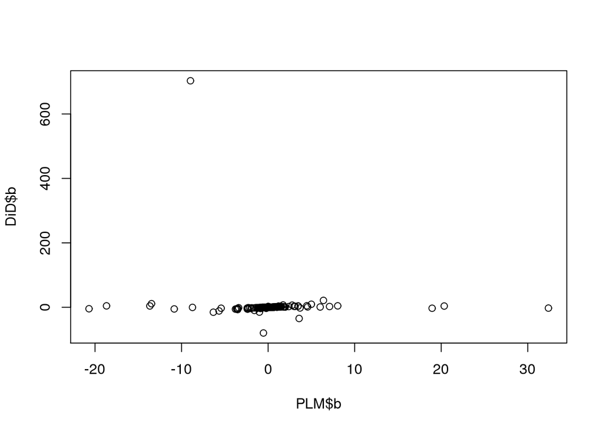

```r
plot(PLM$b, DiD$b)
```

Remove crazy effects

```r
index <- abs(DiD$b) > 2 | abs(PLM$b) > 2
cor(PLM$b[!index], DiD$b[!index])
```

```
## [1] 0.9273311
```

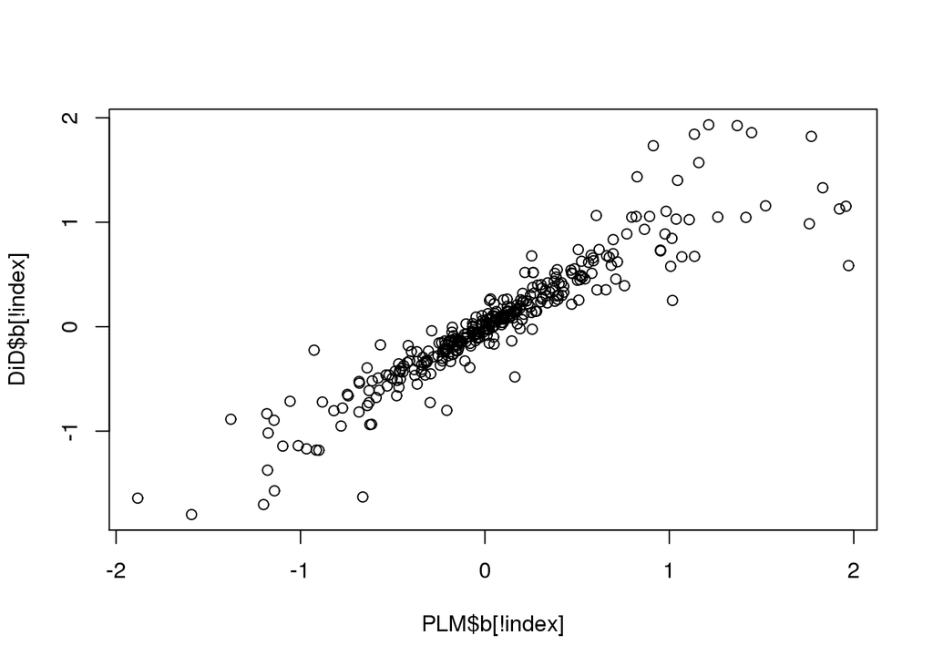

```r
plot(PLM$b[!index], DiD$b[!index])
```

Now meta analyse across individual SNP estimates

```r
meta::metagen(PLM$b, PLM$se)
```

[output not shown]

```r
mr_ivw(DiD$sbx, DiD$sby, DiD$ssex, DiD$ssey)
```

```
## $b
## [1] 0.008135218
##
## $se
## [1] 0.01934216
##
## $pval
## [1] 0.6740507
##
## $nsnp
## [1] 385
##
## $Q
## [1] 430.4995
##
## $Q_df
## [1] 384
##
## $Q_pval
## [1] 0.05066714
```

## Final thoughts

When instruments are very strong the agreement between PLM and DiD is near perfect. That there are larger differences when using weak instruments indicates that the DiD method is likely not accounting for this appropriately, so the standard errors are liable to be associated with confounding for example.

PLM however is extremely slow, making simulations somewhat prohibitive. Moving forwards we can

1. Use PLM for empirical analysis
2. Show theoretically that it is equivalent to DiD in most scenarios
3. Present simulations using DiD to illustrate the solution to the problem of dynastic effects, while explaining that in practice PLM is more appropriate.